# EIS 2026 Variable Atlas

### Confidence votes in own community will be counted as intended

n = 2,909 — Weighted mean 3.28 (95% CI 3.25-3.32) on a 1-4 scale

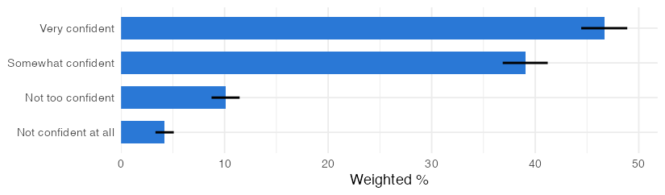

### Confidence votes nationwide will be counted as intended

n = 2,896 — Weighted mean 3.02 (95% CI 2.97-3.06) on a 1-4 scale

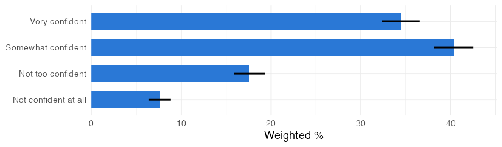

### Confidence own vote will be counted as intended

n = 2,829 — Weighted mean 3.27 (95% CI 3.23-3.30) on a 1-4 scale

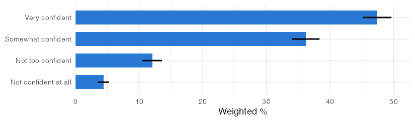

### Confidence votes in own state will be counted as intended

n = 2,902 — Weighted mean 3.21 (95% CI 3.17-3.25) on a 1-4 scale

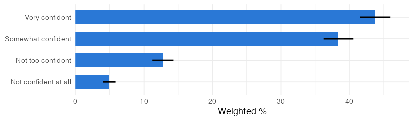

### Educational attainment, three categories

n = 3,144 — Weighted mean 1.58 (95% CI 1.55-1.61) on a 1-3 scale

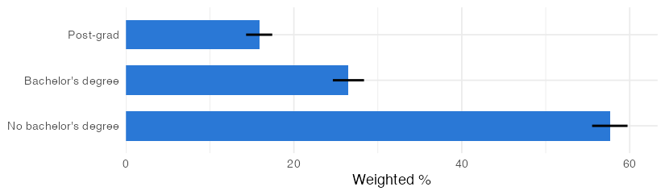

### Educational attainment, nine categories

n = 3,144 — Weighted mean 5.59 (95% CI 5.50-5.69) on a 1-9 scale

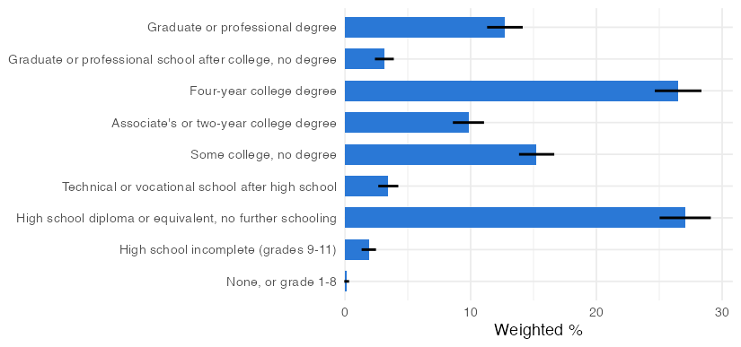

### Generation

n = 3,071 — Weighted mean 2.72 (95% CI 2.67-2.77) on a 1-4 scale

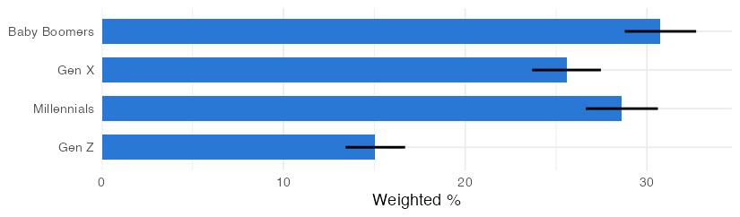

### Political ideology, three categories

n = 2,987 — Weighted mean 2.06 (95% CI 2.02-2.10) on a 1-3 scale

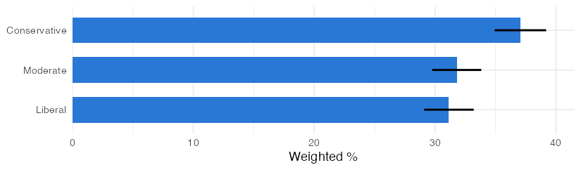

### Political ideology, seven-point scale

n = 2,987 — Weighted mean 4.14 (95% CI 4.06-4.23) on a 1-7 scale

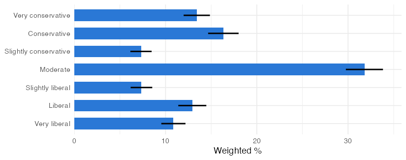

### Household income, three bands

n = 3,144 — Weighted mean 1.81 (95% CI 1.78-1.84) on a 1-3 scale

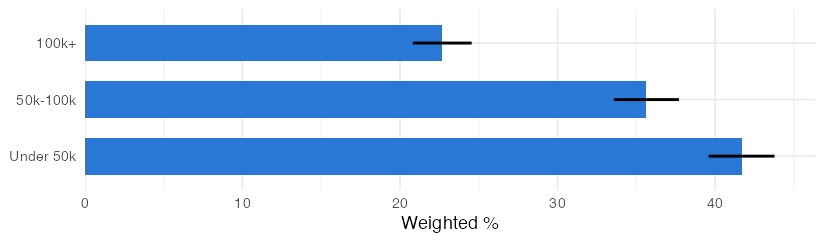

### Household income, six bands

n = 3,144 — Weighted mean 3.76 (95% CI 3.69-3.83) on a 1-6 scale

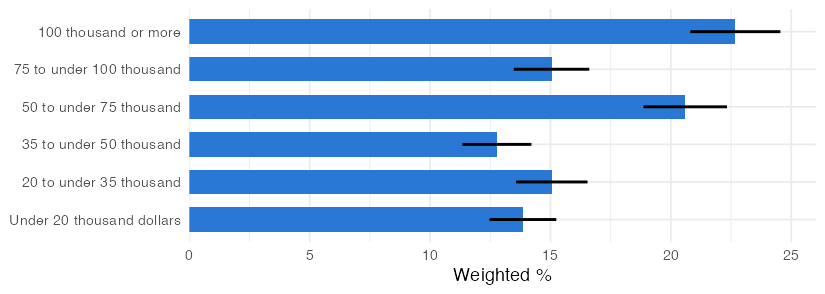

### Household income within the top band, four bands

Base: demInc = 6 ($100 thousand or more) — n = 551 — Weighted mean 1.78 (95% CI 1.69-1.88) on a 1-4 scale

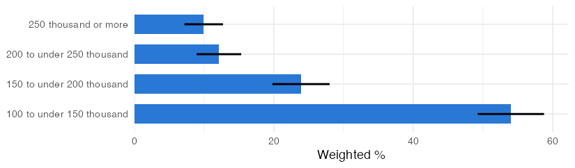

### Supports the MAGA movement

Base: Republicans, including Republican leaners (demPidNoLn = 1 or demPidClos = 2) — n = 1,245 — Weighted mean 2.97 (95% CI 2.90-3.04) on a 1-4 scale

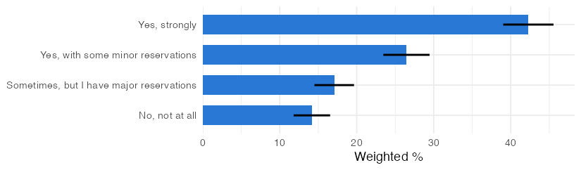

### How often illegal noncitizen voting occurs

n = 2,888 — Weighted mean 3.06 (95% CI 3.01-3.12) on a 1-5 scale

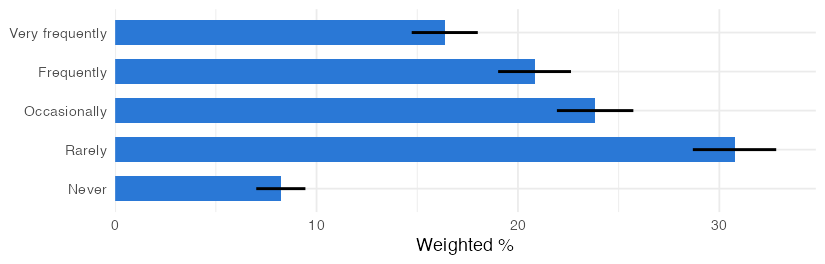

### Party identification, five categories, with independents' leans recovered

n = 3,144 — Weighted mean 3.03 (95% CI 2.96-3.11) on a 1-5 scale

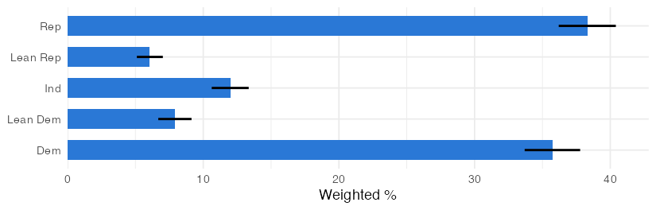

### Party identification, standard seven-point scale from Strong Democrat to Strong Republican

n = 3,144 — Weighted mean 4.05 (95% CI 3.95-4.15) on a 1-7 scale

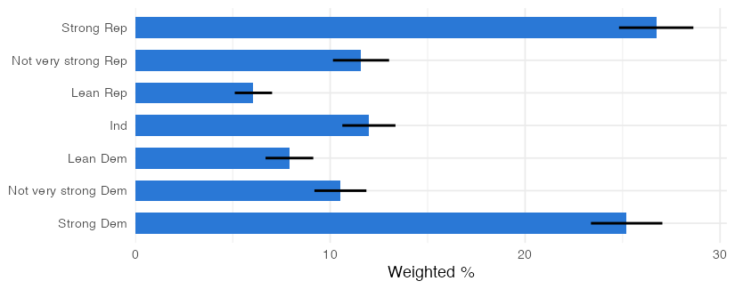

### Party identification strength among partisans

Base: Partisans (xpid3 = 1 or 3) — n = 2,304 — Weighted mean 1.70 (95% CI 1.68-1.72) on a 1-2 scale

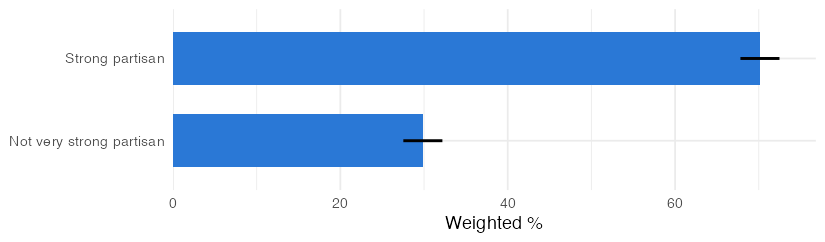

### Considers self a progressive

Base: Democrats, including Democratic leaners (demPidNoLn = 2 or demPidClos = 1) — n = 1,267 — Weighted mean 2.78 (95% CI 2.70-2.85) on a 1-4 scale

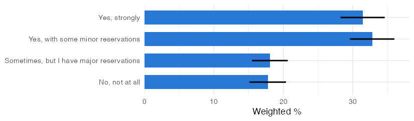

### Community type: urban, suburban, or rural

n = 3,144 — Weighted mean 1.98 (95% CI 1.95-2.01) on a 1-3 scale

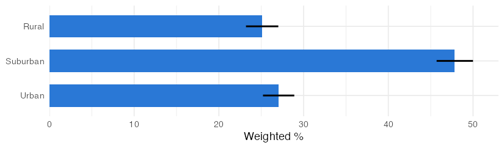

### How often seeks out each kind of election information: Information about how elections are run

n = 3,144 — Weighted mean 2.92 (95% CI 2.86-2.98) on a 1-5 scale

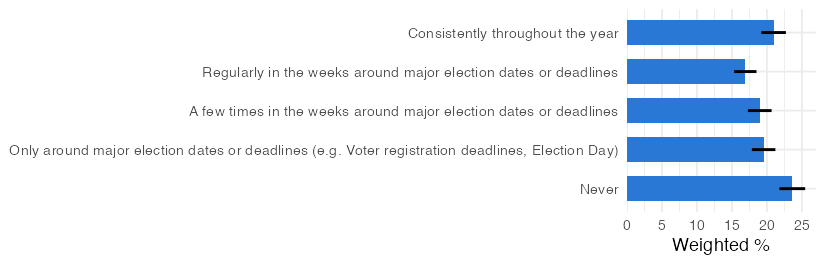

### How often seeks out each kind of election information: Information about how to register and vote

n = 3,144 — Weighted mean 2.81 (95% CI 2.75-2.88) on a 1-5 scale

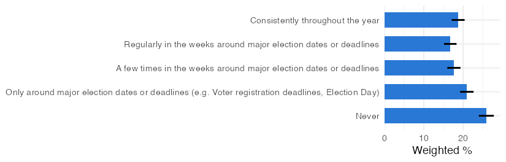

### How often seeks out each kind of election information: Information about who won an election

n = 3,144 — Weighted mean 3.20 (95% CI 3.14-3.25) on a 1-5 scale

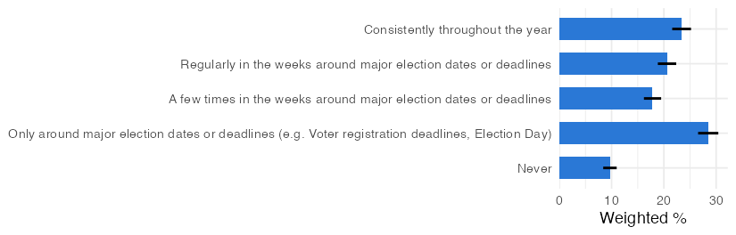

### Support for the Postal Service's August mail-ballot policy change

n = 2,819 — Weighted mean 3.01 (95% CI 2.94-3.07) on a 1-5 scale

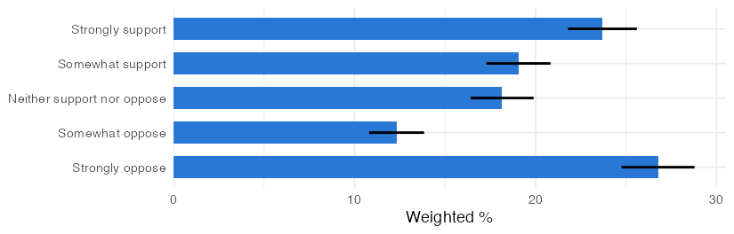

### Agreement that own voting experience is a positive one

n = 2,990 — Weighted mean 4.30 (95% CI 4.26-4.34) on a 1-5 scale

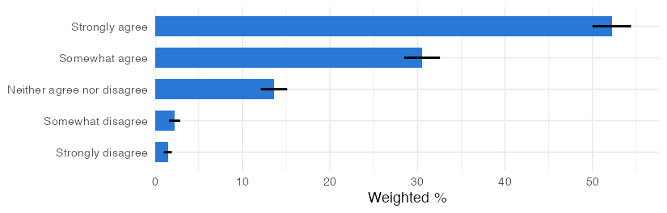

### Self-rated likelihood of voting in the November 2026 midterm elections

n = 3,041 — Weighted mean 8.72 (95% CI 8.62-8.81) on a 1-10 scale

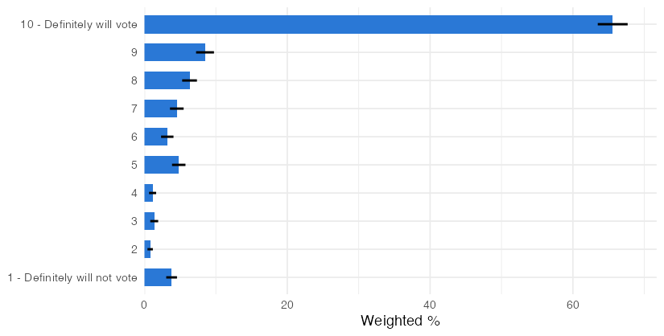

## Nominal, binary, and flag items (51)

### Higher priority: easier for eligible voters, or harder for ineligible voters

n = 3,144

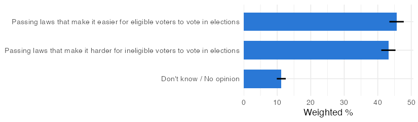

### Which arm of the hidden 50/50 split at BPC38 the respondent was assigned to

n = 3,144

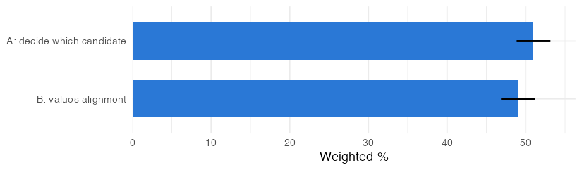

### Was routed to the MAGA-support follow-up, i.e. is a Republican or Republican leaner

n = 3,144

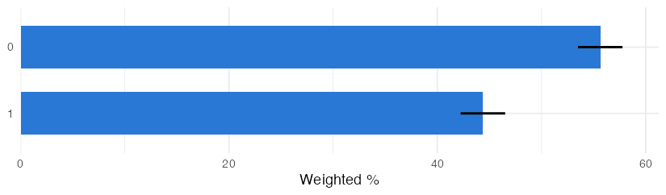

### Was routed to the progressive-identity follow-up, i.e. is a Democrat or Democratic leaner

n = 3,144

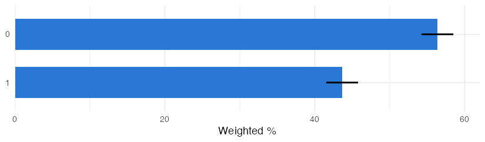

### Whether the country is headed in the right direction

n = 3,144

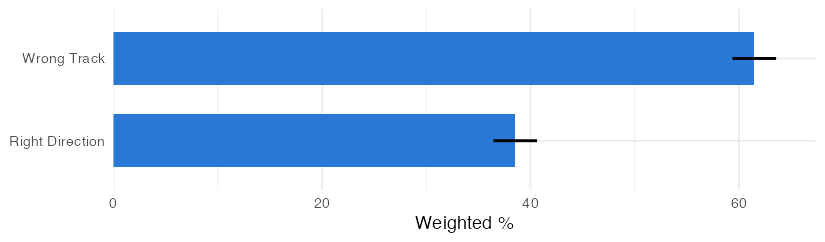

### Has a disability that prevents working

Base: Not currently employed (xdemEmploy in 4:8) — n = 1,550

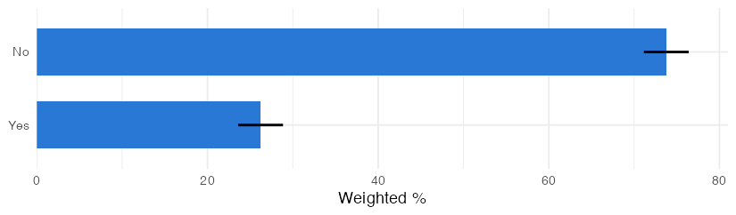

### Employment status

n = 3,144

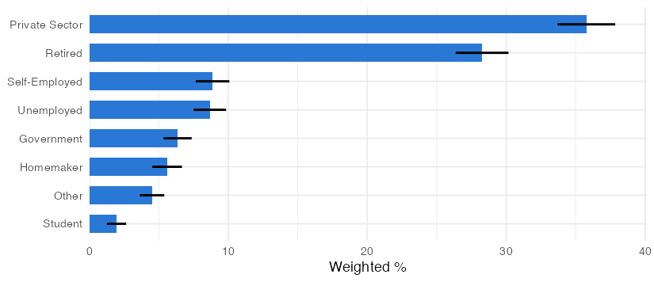

### Describes self as evangelical or born-again Christian

Base: demRelig in {Protestant, Roman Catholic, Something else} — n = 2,036

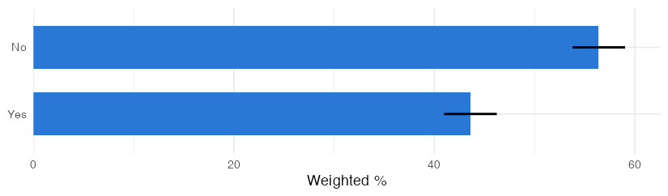

### Took the exclusive 'not interested in election news' anchor, yet seeks election information

n = 3,144

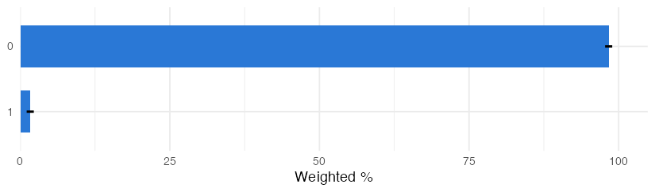

### Says they do not plan to vote, yet rates their own likelihood of voting 8 or higher

n = 3,144

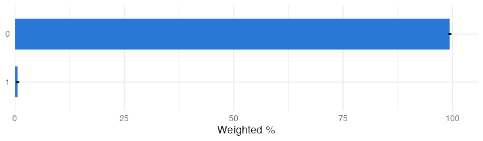

### Gender

n = 3,140

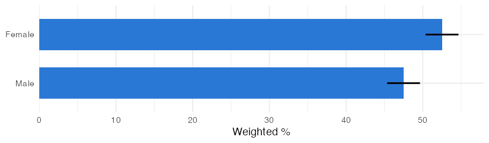

### Type of health insurance coverage

Base: demInsured = 1 (covered) — n = 2,834

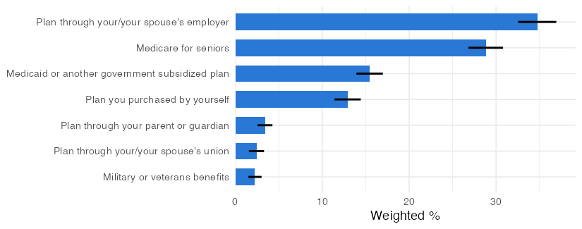

### Covered by health insurance

n = 3,144

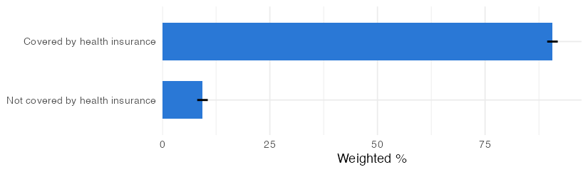

### Covered by health insurance, vendor recode duplicating demInsured

n = 3,144

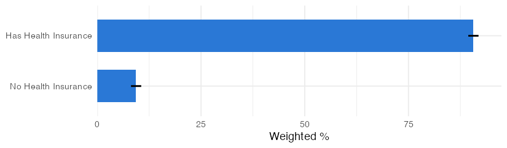